# xGEMS tutorial 2 — titrating basalt into seawater (250 °C, 1000 bar)

The whole titration is one idea — rescale basalt and add it to seawater:

```
mix = seawater + basalt.set_quantity(n, "g")
gems.equilibrate(T, P, mix)
```

The y-axis is each solid's share of the **total solids volume**

```
cV = V(system) − V(aq_gen) − V(fluid_gen)     # everything that is not fluid
yp = V(phase) / cV
```

> Runs against your local `xgems` env + `gems_files/SW-B_titr3-dat.lst`; not executed here.

## 1. Setup

```python
import numpy as np
import pandas as pd
import matplotlib.pyplot as plt
from xgems import ChemicalEngineDicts, Material

gems = ChemicalEngineDicts("gems_files/SW-B_titr3-dat.lst")

T = 250.0 + 273.15     # K   (250 °C)
P = 1000e5             # Pa  (1000 bar)
```

## 2. Seawater and basalt (as in tutorial 1)

```python
seawater = Material(gems, "seawater")
seawater.add({
    "C":  0.001966361,
    "Ca": 0.01037339,
    "Cl": 0.5467499,
    "H":  107.122,
    "K":  0.01020831,
    "Mg": 0.05282088,
    "Na": 0.4689999,
    "O":  53.67904,
    "S":  0.02823655,
})

basalt_metals = Material(gems, "basalt_metals")
basalt_metals.add({
    "Ag": 7.524747e-06,
    "Al": 2.840883,
    "Au": 4.120898e-06,
    "Ca": 2.191539,
    "Cu": 0.01277312,
    "Fe": 1.469142,
    "K":  0.06493447,
    "Mg": 2.11037,
    "Na": 0.6493447,
    "O":  26.99651,
    "Pb": 0.03917379,
    "Si": 8.116809,
    "Ti": 0.1623362,
    "Zn": 0.1241482,
})
```

```
Material('basalt_metals', 14 constituents, 1000 g, 44.778 mol)
```

The solid phases we track (your GEMS phase list). At each step we read every phase volume, work out the total solids volume `cV`, and store each solid's fraction `V(phase) / cV`.

```python
SOLID_PHASES = [
    "Alkali Feldspar", "Plagioclase", "Chlorite", "Cpx", "Epidote", "Quartz",
    "Titanite", "Hematite", "Magnetite", "Prehnite", "Anhydrite",
    "Gold", "Silver", "Acanthite", "Bornite", "Chalcocite", "Chalcopyrite",
    "Covellite", "Galena", "Pyrite", "Sphalerite", "Dolomite", "Calcite", "Paragonite"
]

grams = range(50, 501,10)          # 1 to 500 g of basalt


saponites = ["Ca-Saponite", "Fe-Saponite", "K-Saponite",
             "Mg-Saponite", "Na-Saponite"]

gems.suppress_multiple_phases(saponites, min_amount=0.0, max_amount=0.0)

rows = []
for n in grams:
    mix = seawater.set_quantity(1.0, "kg") + basalt_metals.set_quantity(n, "g")
    gems.cold_start()
    gems.equilibrate(T, P, mix)

    pv = gems.phases_volume                                   # {phase: volume in m3}
    cV = gems.system_volume - pv["aq_gen"] - pv["fluid_gen"]  # total solids volume
    rows.append({p: pv.get(p, 0.0) / cV for p in SOLID_PHASES})

yp = pd.DataFrame(rows, index=list(grams))     # volume fraction of solids
yp.index.name = "g_basalt"
yp.head()
```

| g_basalt | Alkali Feldspar | Plagioclase | Chlorite | Cpx | Epidote | Quartz | Titanite | Hematite | Magnetite | Prehnite | ... | Bornite | Chalcocite | Chalcopyrite | Covellite | Galena | Pyrite | Sphalerite | Dolomite | Calcite | Paragonite |
| --- | --- | --- | --- | --- | --- | --- | --- | --- | --- | --- | --- | --- | --- | --- | --- | --- | --- | --- | --- | --- | --- |
| 50 | 0.166647 | 0.166647 | 0.420356 | 0.154847 | 0.007778 | 0.0 | 0.023944 | 0.0 | 0.0 | 0.0 | ... | 0.0 | 0.000439 | 0.0 | 0.0 | 0.002799 | 0.0 | 0.000000 | 0.0 | 0.0 | 0.0 |
| 60 | 0.165291 | 0.165291 | 0.394672 | 0.164627 | 0.035642 | 0.0 | 0.024363 | 0.0 | 0.0 | 0.0 | ... | 0.0 | 0.000456 | 0.0 | 0.0 | 0.003091 | 0.0 | 0.000389 | 0.0 | 0.0 | 0.0 |
| 70 | 0.164047 | 0.164047 | 0.375737 | 0.171564 | 0.056989 | 0.0 | 0.024677 | 0.0 | 0.0 | 0.0 | ... | 0.0 | 0.000463 | 0.0 | 0.0 | 0.003145 | 0.0 | 0.000840 | 0.0 | 0.0 | 0.0 |
| 80 | 0.163101 | 0.163101 | 0.361225 | 0.176886 | 0.073341 | 0.0 | 0.024918 | 0.0 | 0.0 | 0.0 | ... | 0.0 | 0.000469 | 0.0 | 0.0 | 0.003185 | 0.0 | 0.001183 | 0.0 | 0.0 | 0.0 |
| 90 | 0.162358 | 0.162358 | 0.349748 | 0.181099 | 0.086263 | 0.0 | 0.025109 | 0.0 | 0.0 | 0.0 | ... | 0.0 | 0.000474 | 0.0 | 0.0 | 0.003218 | 0.0 | 0.001454 | 0.0 | 0.0 | 0.0 |

5 rows × 24 columns

## 4. Plot — solid volume fractions vs grams of basalt

Stacked areas, styled like the GEMS titration plot. Phases that never appear (e.g. the trace ore minerals) are left out of the legend.

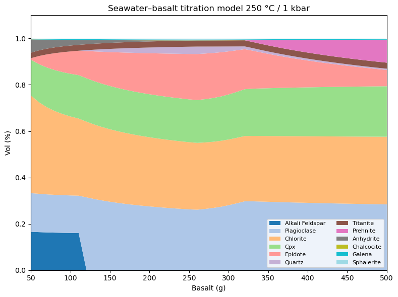

```python
present = [p for p in SOLID_PHASES if yp[p].max() > 1e-6]   # drop phases that stay at 0

ax = yp[present].plot.area(figsize=(8, 6), cmap="tab20", linewidth=0)
ax.set_xlim(50, 500)          # match the GEMS figure (drop the noisy low-basalt end)
ax.set_ylim(0, 1.10)
ax.set_xlabel("Basalt (g)")
ax.set_ylabel("Vol (%)")      # fraction of total solids (0–1), as in GEM-Selektor
ax.set_title("Seawater–basalt titration model 250 °C / 1 kbar")
ax.legend(fontsize=8, ncol=2, loc="lower right")
plt.tight_layout(); plt.show()
```